# IMCMapper-Functions

Nicolas Damond

2018-09-24

# MAIN FUNCTIONS

**- CellMap:** Displays 1 to 3 cell populations

**- ChannelHM:** Heatmap 1 to 3 channels

**- CellsAndCounts:** Heatmap 1 channel + highlight the borders of 1 to 3 cell populations

**- ClusterDisplay:** Display cell clusters (and unique continuous values)

**- IMCDisplay:** Display 1 to 3 raw IMC images

**- CellsandIMC:** Display 1 IMC image + highlight the borders of 1 to 3 cell populations

**- IMCandCells:** Display 1 to 3 IMC images + highlight the borders of 1 cell population

# GENERAL REQUIREMENTS

### R packages

- “data.table”
- “EBImage”

### CellProfiler data

- Cell masks (16-bit tiff files).
- When exporting CSV from CellProfiler, in “Select measurements” > “Image”, you have to select FileName, PathName and Metadata.
- This will generate an “Image.csv” file, which is required to run this script.

### A data set in the data.table format

- The cell objects must be the same as those used to create the masks in CellProfiler.
- Must contain an “image” column where the values correspond to the image names in the “Metadata” column of your “Image.csv” file.
- Must contain a “cell id” column in the format “###_nnn“, where ### is the name of the image in the”image" column and nnn is the number of the cell.

### Example of cell data

```r
cells
```

```
#>                id core channel c_counts_scaled CellType case      dist
#>        1:   A01_1  A01      H3      0.19518141   acinar 6362 -274.4886
#>        2:   A01_1  A01     SMA      0.05113341   acinar 6362 -274.4886
#>        3:   A01_1  A01     INS      0.05840445   acinar 6362 -274.4886
#>        4:   A01_1  A01    CD38      0.07523585   acinar 6362 -274.4886
#>        5:   A01_1  A01    CD44      0.25279378   acinar 6362 -274.4886
#>       ---
#> 67525008: Y31_999  Y31     pRB      0.10169618   ductal 6278 -113.6375
#> 67525009: Y31_999  Y31  cPARP1      0.14420100   ductal 6278 -113.6375
#> 67525010: Y31_999  Y31   Ir191      0.31884175   ductal 6278 -113.6375
#> 67525011: Y31_999  Y31   Ir193      0.33521222   ductal 6278 -113.6375
#> 67525012: Y31_999  Y31     Unc              NA   ductal 6278 -113.6375
```

# OPTIONAL ARGUMENTS

### Those arguments can be passed to any of the functions below

**Options for image display**  
*method* — ‘raster’ or ‘browser’ option from the EBImage package to display the images in a separate (new tab) JavaScript viewer (‘browser’) or directly in R (‘raster’) (default = ‘raster’).

**Arguments for saving the images**  
*save* — TRUE/FALSE: should the images be saved (default = FALSE).

*path* — path to the folder in which the images should be saved. If the folder does not exist it will be created (default = working directory).

*type* — ‘png’, ‘jpeg’ or ‘tiff’: format of the saved images (default = ‘png’).

**Arguments for legend customization**  
*leg* — TRUE/FALSE: should a color legend be displayed. The legend will be displayed as a separate image (default = TRUE). If “save” is set to TRUE, the legend will be saved together with the pictures as a .png image.

*legend* — vector containing the names of the elements displayed in the legend

*fill* — vector containing the colors to be displayed in the legend

*border* — vector containing the color of the legend borders

*cex* — size of the text of the legend (character expansion)

*+ any other argument taken by the “legend” function (see ?legend)*

**Arguments for label customization**  
*label* — TRUE/FALSE: should the name of the image be displayed on the image (default = TRUE). Doesn’t work with the ‘browser’ method. The label is also not displayed on saved images.

*label.txt* — text to be display on the image label. The same text will be displayed on all images (default = name of the image)

*label.color* — color of the image label displayed on the image

*label.cex* — size of the text of the image name label (character expansion)

*label.x* — x position of the image name label

*label.y* — y position of the image name label

# FUNCTIONS

## CellMap

Display 1 to 3 cell populations

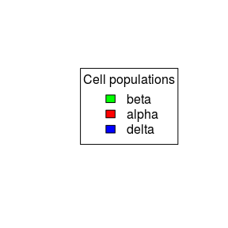

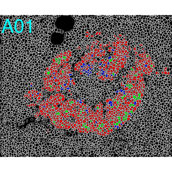

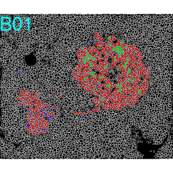

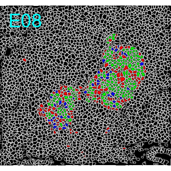

```r
# Vectors containing the ids of cells to display
cell.pop.1 <- unique(cells[core %in% c("A01","B01","E08") & CellType=='beta']$id)
cell.pop.2 <- unique(cells[core %in% c("A01","B01","E08") & CellType=='alpha']$id)
cell.pop.3 <- unique(cells[core %in% c("A01","B01","E08") & CellType=='delta']$id)

CellMap(x = cells,
        id.col = 'id',
        cell1 = cell.pop.1,
        cell2 = cell.pop.2,
        cell3 = cell.pop.3,
        meta = '/home/nicolasd/Data/CM2017/cpoutput/All/All_ImagePathMapping.csv',
        path.col = 'ObjectsPathName_FilteredRescaledCellsExpand',
        file.col = 'ObjectsFileName_FilteredRescaledCellsExpand',
        slide.col = 'Metadata_Slide',
        borders = TRUE,
        legend = c('beta', 'alpha', 'delta'),
        label.color = "cyan",
        cex=1,
        label.cex=2,
        label.x=85
        # Optional arguments to save the images
        # save = TRUE,
        # path = '/home/nicolasd/Data/CM2017/CellMapper'
)
```

## ChannelHM

Heatmap 1 to 3 channels

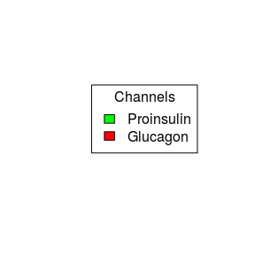

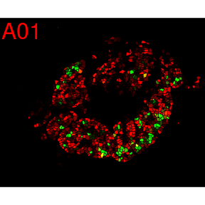

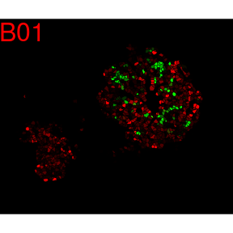

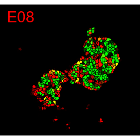

```r
# List of images to display
image.list <- c("A01","B01","E08")

ChannelHM(x = cells,
          id.col = 'id',
          counts.col = 'c_counts_scaled',
          channel.col = 'channel',
          image.col = 'core',
          im.list = image.list,
          ch1 = 'PIN',
          ch2 = 'GCG',
          # ch3 = 'SST',
          bcg1 = c(0, 4, 2),
          bcg2 = c(0, 4, 2),
          bcg3 = c(0, 4, 2),
          meta = '/home/nicolasd/Data/CM2017/cpoutput/All/All_ImagePathMapping.csv',
          path.col = 'ObjectsPathName_FilteredRescaledCellsExpand',
          file.col = 'ObjectsFileName_FilteredRescaledCellsExpand',
          slide.col = 'Metadata_Slide',
          borders = FALSE,
          legend = c("Proinsulin", "Glucagon", "Somatostatin"),
          cex=1,
          label.cex=2,
          label.x=85
          # save = TRUE,
          # path = '/home/nicolasd/Data/CM2017/CellMapper'
)
```

## CellsAndCounts

Heatmap one channel and highlight the borders of 1 to 3 cell populations.  
Known bug: when intensity is high (white cells), the borders of cells that should be displayed become dimmer and can be hard/impossible to see.

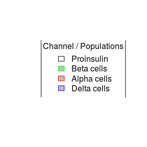

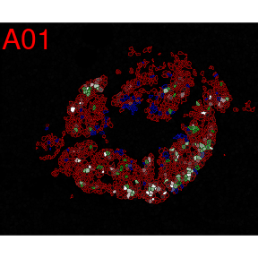

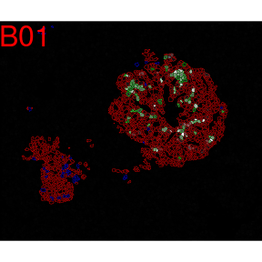

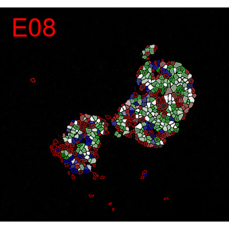

```r
# Vectors containing the ids of cells to display
cell.pop.1 <- unique(cells[core %in% c("A01","B01","E08") & CellType=='beta']$id)
cell.pop.2 <- unique(cells[core %in% c("A01","B01","E08") & CellType=='alpha']$id)
cell.pop.3 <- unique(cells[core %in% c("A01","B01","E08") & CellType=='delta']$id)

CellsAndCounts(x = cells,
               id.col = 'id',
               image.col = 'core',
               channel.col = 'channel',
               counts.col = 'c_counts_scaled',
               ch = 'PIN',
               cell1 = cell.pop.1,
               cell2 = cell.pop.2,
               cell3 = cell.pop.3,
               meta = '/home/nicolasd/Data/CM2017/cpoutput/All/All_ImagePathMapping.csv',
               path.col = 'ObjectsPathName_FilteredRescaledCellsExpand',
               file.col = 'ObjectsFileName_FilteredRescaledCellsExpand',
               slide.col = 'Metadata_Slide',
               bcg = c(0, 2, 1),
               legend = c("Proinsulin", "Beta cells", "Alpha cells", "Delta cells"),
               cex=1,
               label.cex=2,
               label.x=85
               # save = TRUE,
               # path = '/home/nicolasd/Data/CM2017/CellMapper'
)
```

## ClusterDisplay

Display cell clusters or cell types

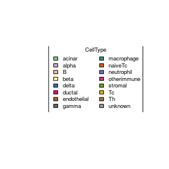

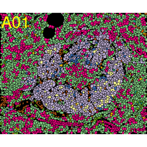

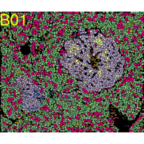

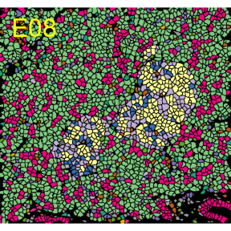

```r
# List of images to display
image.list <- c("A01","B01","E08")

ClusterDisplay(x = cells,
               im.list = image.list,
               id.col = 'id',
               image.col = 'core',
               cluster.col = 'CellType',
               meta = '/home/nicolasd/Data/CM2017/cpoutput/All/All_ImagePathMapping.csv',
               path.col = 'ObjectsPathName_FilteredRescaledCellsExpand',
               file.col = 'ObjectsFileName_FilteredRescaledCellsExpand',
               slide.col = 'Metadata_Slide',
               borders = FALSE,
               bcg=c(0,1,1),
               label.color="yellow",
               cex=0.6,
               label.cex=2,
               label.x=85
               # save = TRUE,
               # path = '/home/nicolasd/Data/CM2017/CellMapper'
)
```

### Optional palettes for cluster display

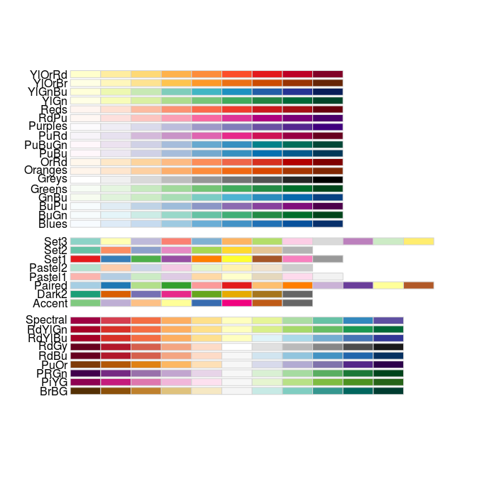

```r
# Optional palettes from the RColorBrewer package
require(RColorBrewer)
RColorBrewer::display.brewer.all()
```

```r
# # Optional palettes from the viridis package
# require(viridisLite)
# image(1:400, 1, as.matrix(1:400), col = c(viridis(100, option = "D"), rep("#FFFFFF",10), viridis(100, option = "A"), rep("#FFFFFF",10),
#                                           viridis(100, option = "B"), rep("#FFFFFF",10), viridis(100, option = "C")),
#       main = c("viridis   magma   inferno   plasma"),
#       xlab = "", ylab = "", xaxt = "n", yaxt = "n", bty = "n")

# Example of custom palette
color_clusters <- c("#DC050C", "#FB8072", "#1965B0", "#7BAFDE", "#882E72",
                   "#B17BA6", "#FF7F00", "#FDB462", "#E7298A", "#E78AC3",
                   "#33A02C", "#B2DF8A", "#55A1B1", "#8DD3C7", "#A6761D",
                   "#E6AB02", "#7570B3", "#BEAED4", "#666666", "#999999",
                   "#aa8282", "#d4b7b7", "#8600bf", "#ba5ce3", "#808000",
                   "#aeae5c", "#1e90ff", "#00bfff", "#56ff0d", "#ffff00")

# plot(1, type="n", axes=FALSE, xlab="", ylab="")
# legend(legend=seq(1:30), x=1, y=1, fill=color_clusters, ncol=4, cex=1)
```

## IMCDisplay

Display one to three channel(s) from an IMC image

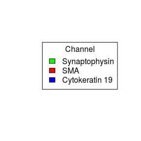

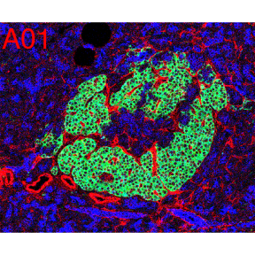

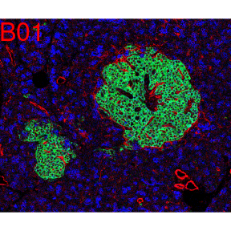

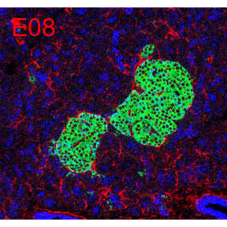

```r
# List of images to display
image.list <- c("A01","B01","E08")

IMCDisplay(x = cells,
           im.list = image.list,
           image.col = 'core',
           ch1 = 'Syn',
           ch2 = 'SMA',
           ch3 = 'CK19',
           bcg1 = c(0, 0.05, 1),
           bcg2 = c(0, 0.3, 1),
           bcg3 = c(0, 1, 1),
           meta = '/home/nicolasd/Data/CM2017/cpoutput/All/All_ImagePathMapping.csv',
           path.col = 'ObjectsPathName_FilteredRescaledCellsExpand',
           file.col = 'ObjectsFileName_FilteredRescaledCellsExpand',
           slide.col = 'Metadata_Slide',
           borders = FALSE,
           legend = c("Synaptophysin", "SMA", "Cytokeratin 19"),
           cex=1,
           label.cex=2,
           label.x=85
           # method = 'browser'
           # save = TRUE,
           # path = '/home/nicolasd/Data/CM2017/CellMapper'
)
```

## CellsandIMC

Display 1 IMC image + highlight the borders of 1 to 3 cell populations

### Additional requirements

The channel images should be in the same folder as the masks (one channel per image), similar to the histoCAT folder structure

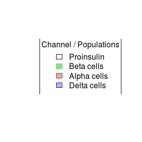

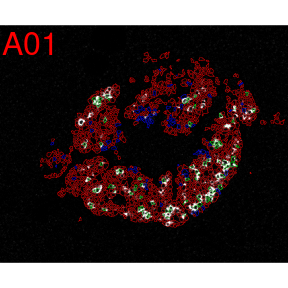

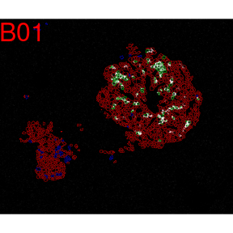

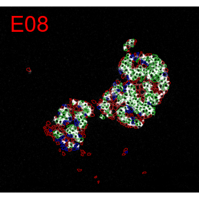

```r
# Vectors containing the ids of cells to display
cell.pop.1 <- unique(cells[core %in% c("A01","B01","E08") & CellType=='beta']$id)
cell.pop.2 <- unique(cells[core %in% c("A01","B01","E08") & CellType=='alpha']$id)
cell.pop.3 <- unique(cells[core %in% c("A01","B01","E08") & CellType=='delta']$id)

CellsandIMC(x = cells,
            id.col = 'id',
            image.col = 'core',
            ch = 'Pin',
            cell1 = cell.pop.1,
            cell2 = cell.pop.2,
            cell3 = cell.pop.3,
            meta = '/home/nicolasd/Data/CM2017/cpoutput/All/All_ImagePathMapping.csv',
            path.col = 'ObjectsPathName_FilteredRescaledCellsExpand',
            file.col = 'ObjectsFileName_FilteredRescaledCellsExpand',
            slide.col = 'Metadata_Slide',
            bcg = c(0, 0.05, 1),
            legend = c("Proinsulin", "Beta cells", "Alpha cells", "Delta cells"),
            cex=1,
            label.cex=2,
            label.x=85
            # save = TRUE,
            # path = '/home/nicolasd/Data/CM2017/CellMapper'
)
```

## IMCandCells

### Additional requirements

The channel images should be in the same folder as the masks (one channel per image), similar to the histoCAT folder structure

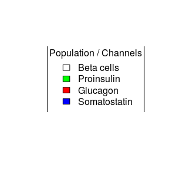

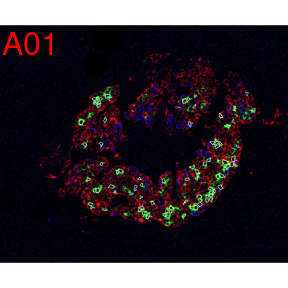

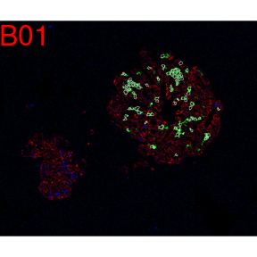

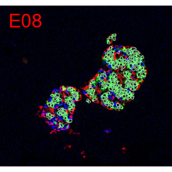

```r
# Vectors containing the ids of cells to display
cell.pop.1 <- unique(cells[core %in% c("A01","B01","E08") & CellType=='beta']$id)

IMCandCells(x = cells,
            id.col = 'id',
            image.col = 'core',
            cell1 = cell.pop.1,
            ch1 = 'Pin',
            ch2 = 'Gcg',
            ch3 = 'Sst',
            bcg1 = c(0, 0.05, 1),
            bcg2 = c(0, 0.1, 1),
            bcg3 = c(0, 0.2, 1),
            meta = '/home/nicolasd/Data/CM2017/cpoutput/All/All_ImagePathMapping.csv',
            path.col = 'ObjectsPathName_FilteredRescaledCellsExpand',
            file.col = 'ObjectsFileName_FilteredRescaledCellsExpand',
            slide.col = 'Metadata_Slide',
            legend = c("Beta cells", "Proinsulin", "Glucagon", "Somatostatin"),
            cex=1,
            label.cex=2,
            label.x=85
            # method = 'browser'
            # save = TRUE,
            # path = '/home/nicolasd/Data/CM2017/CellMapper'
)
```